# Text Analysis of Tripadvisor Hotel Reviews

This notebook demonstrates simple descriptive analytics techniques for analyzing a significant amount of text data.

## Goals:

```r
library(tidyverse)
library(ggplot2)
library(tidytext)
library(wordcloud)
library(RColorBrewer)
library(gridExtra)
```

# Dataset

- 20K crawled reviews with rating (1-5) from Tripadvisor

**creadits: Alam, M. H., Ryu, W.-J., Lee, S., 2016. Joint multi-grain topic sentiment: modeling semantic aspects for online reviews. Information Sciences 339, 206–223.**

#### Objective

- Explore aspects that make hotels good or bad

```r
reviews <- read_csv("../input/trip-advisor-hotel-reviews/tripadvisor_hotel_reviews.csv")
```

```r
head(reviews,3)
```

A tibble: 3 × 2

| Review <chr> | Rating <dbl> |
| --- | --- |
| nice hotel expensive parking got good deal stay hotel anniversary, arrived late evening took advice previous reviews did valet parking, check quick easy, little disappointed non-existent view room roo… | 4 |
| ok nothing special charge diamond member hilton decided chain shot 20th anniversary seattle, start booked suite paid extra website description not, suite bedroom bathroom standard hotel room, took pri… | 2 |
| nice rooms not 4* experience hotel monaco seattle good hotel n't 4* level.positives large bathroom mediterranean suite comfortable bed pillowsattentive housekeeping staffnegatives ac unit malfunctione… | 3 |

```r
reviews %>%
    count(Rating)
reviews %>%
    summarize(rating_mean = mean(Rating))
quantile(reviews$Rating)
```

A spec_tbl_df: 5 × 2

| Rating <dbl> | n <int> |
| --- | --- |
| 1 | 1421 |
| 2 | 1793 |
| 3 | 2184 |
| 4 | 6039 |
| 5 | 9054 |

A tibble: 1 × 1

| rating_mean <dbl> |
| --- |
| 3.952223 |

**0%**

1

**25%**

3

**50%**

4

**75%**

5

**100%**

5

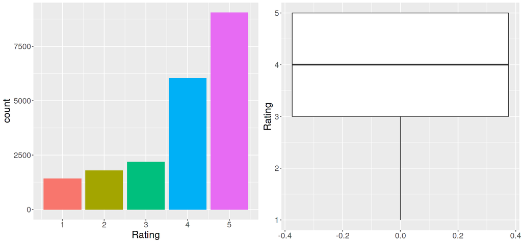

```r
options(repr.plot.width = 15, repr.plot.height = 7)
reviews_barplot <- ggplot(data=reviews, aes(x=Rating, fill=as.factor(Rating)))+geom_bar(show.legend = FALSE) + theme(text = element_text(size=20))
reviews_boxplot <- ggplot(data=reviews, aes(y=Rating, fill=Rating))+geom_boxplot() + theme(text = element_text(size=20))
grid.arrange(reviews_barplot, reviews_boxplot, ncol=2)
```

### Create structure

- Split column(reviews) to tokens (One word per row)
- Remove stopwords
- Count words and arrange in descending order

```r
tidy_review <- reviews %>%
    unnest_tokens(word, Review) %>%
    anti_join(stop_words)

tidy_review %>%
    count(word) %>%
    filter(n>300)%>%
    arrange(desc(n))
```

A spec_tbl_df: 973 × 2

| word <chr> | n <int> |
| --- | --- |
| hotel | 49016 |
| n't | 18984 |
| staff | 16260 |
| stay | 15176 |
| nice | 12460 |
| location | 11095 |
| stayed | 10467 |
| service | 10088 |
| time | 9901 |
| night | 9899 |
| beach | 9765 |
| day | 9680 |
| clean | 9407 |
| breakfast | 9336 |
| food | 9097 |
| resort | 7976 |
| pool | 7379 |
| people | 6782 |
| friendly | 6764 |
| 2 | 6729 |
| walk | 6196 |
| excellent | 6037 |
| bar | 5489 |
| helpful | 5477 |
| 5 | 5321 |
| restaurant | 5254 |
| 3 | 5193 |
| restaurants | 5009 |
| bathroom | 4994 |
| water | 4970 |
| ⋮ | ⋮ |
| closer | 311 |
| summer | 311 |
| nightly | 310 |
| worried | 310 |
| biggest | 309 |
| catch | 309 |
| sunday | 309 |
| apparently | 308 |
| sofa | 307 |
| concerned | 306 |
| meat | 306 |
| similar | 306 |
| numerous | 305 |
| reserve | 305 |
| christmas | 304 |
| dated | 304 |
| friday | 304 |
| meant | 304 |
| seasons | 304 |
| informed | 303 |
| normal | 303 |
| setting | 303 |
| talking | 303 |
| travelled | 303 |
| woman | 303 |
| missed | 302 |
| office | 302 |
| fit | 301 |
| linens | 301 |
| snack | 301 |

### Add custom stopwords

- Create custom stopwords object (tribble)
- Combine custom_sw and stopwords (bind_rows)

```r
custom_sw <- tribble(
    ~word, ~lexicon,
    "hotel", "CUSTOM",
    "n't", "CUSTOM",
    "1", "CUSTOM",
    "2", "CUSTOM",
    "5", "CUSTOM",
    "3", "CUSTOM",
    "4", "CUSTOM",
    "10", "CUSTOM",
    "stay", "CUSTOM",
    "stayed", "CUSTOM",
)

stop_words2 <- stop_words %>%
    bind_rows(custom_sw)
```

### Create structure again

- Using stop_words2 in anti_join()

```r
tidy_review2 <- reviews %>%
    unnest_tokens(word, Review) %>%
    anti_join(stop_words2)

tidy_review2 %>%
    count(word) %>%
    filter(n>300) %>%
    arrange(desc(n))
```

A spec_tbl_df: 963 × 2

| word <chr> | n <int> |
| --- | --- |
| staff | 16260 |
| nice | 12460 |
| location | 11095 |
| service | 10088 |
| time | 9901 |
| night | 9899 |
| beach | 9765 |
| day | 9680 |
| clean | 9407 |
| breakfast | 9336 |
| food | 9097 |
| resort | 7976 |
| pool | 7379 |
| people | 6782 |
| friendly | 6764 |
| walk | 6196 |
| excellent | 6037 |
| bar | 5489 |
| helpful | 5477 |
| restaurant | 5254 |
| restaurants | 5009 |
| bathroom | 4994 |
| water | 4970 |
| trip | 4953 |
| bed | 4927 |
| recommend | 4850 |
| beautiful | 4675 |
| view | 4674 |
| floor | 4616 |
| desk | 4443 |
| ⋮ | ⋮ |
| closer | 311 |
| summer | 311 |
| nightly | 310 |
| worried | 310 |
| biggest | 309 |
| catch | 309 |
| sunday | 309 |
| apparently | 308 |
| sofa | 307 |
| concerned | 306 |
| meat | 306 |
| similar | 306 |
| numerous | 305 |
| reserve | 305 |
| christmas | 304 |
| dated | 304 |
| friday | 304 |
| meant | 304 |
| seasons | 304 |
| informed | 303 |
| normal | 303 |
| setting | 303 |
| talking | 303 |
| travelled | 303 |
| woman | 303 |
| missed | 302 |
| office | 302 |
| fit | 301 |
| linens | 301 |
| snack | 301 |

### Wordcloud

- Graphic representation of the keywords

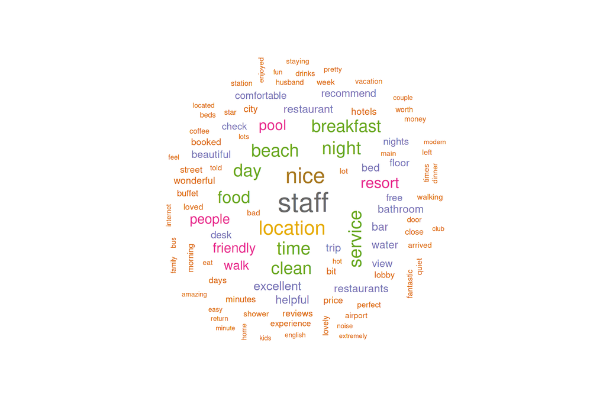

```r
options(repr.plot.width = 15, repr.plot.height = 10)
word_counts <- tidy_review2 %>%
    count(word)

wordcloud(
        words = word_counts$word,
        freq = word_counts$n,
        min.freq = 100,
        max.words = 100,
        random.order=FALSE,
        colors=brewer.pal(8, "Dark2")
)
```

### Rating word count

- Inspect each ratings most frequent words
- This gives a good indication of what to focus on as a first step in developing operations.

```r
word_counts_rating <- tidy_review2 %>%
    count(word, Rating) %>%
    group_by(Rating) %>%
    top_n(15,n) %>%
    ungroup() %>%
    mutate(Rating = as.factor(Rating),
           word = reorder_within(word, n, Rating))
```

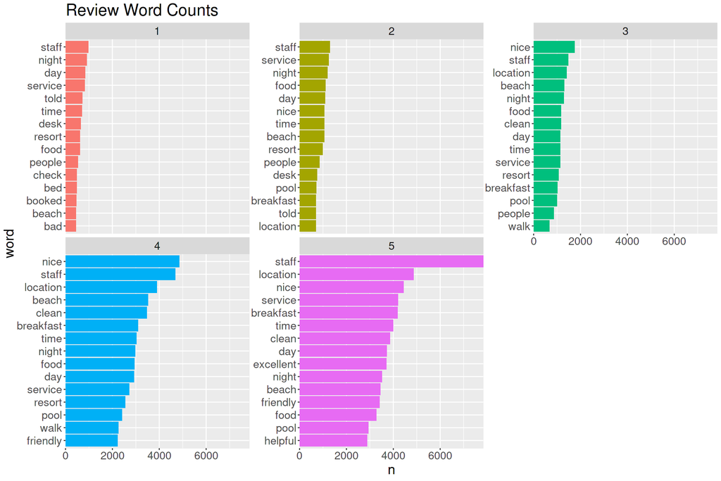

```r
options(repr.plot.width = 15, repr.plot.height = 10)
ggplot(word_counts_rating, aes(x = word, y = n, fill = Rating)) +
    geom_col(show.legend = FALSE) +
    facet_wrap(~ Rating, scales = "free_y", ncol=3) +
    coord_flip() +
    scale_x_reordered() +
    scale_y_continuous(expand = c(0,0)) +
    ggtitle("Review Word Counts") +
    theme(text = element_text(size=20))
```